# Large_data_in_Excel

### We've received some messy OD<sub>600</sub> data of a yeast culture from a lab partner

Let's see if we can identify some trends in our "messy" data based on our knowledge of precision and accuracy

### Hopefully this lab will become useful to you again next year when you take Unit Operations:

*The production engineers have asked us to provide them with recommendations for the conditions (i.e. sugar concentration, pH, yeast concentration, temperature etc.) that should be used in the production fermentation vessels.*

--bioreactor memo, unit ops lab

*The fermenter is a reaction vessel that has controls temperature, pH, and dissolved oxygen [..] Temperature, dissolved oxygen (DO), and pH probes communicate the solution’s conditions to the computer*

--bioreactor SOP, unit ops lab

## We will consider the following while analyzing our data

[figure not shown]

- Use split screen
  - load class_data.csv from the catalyst website into excel
  - go to view, split
  - scroll bottom pane to bottom of sheet
  - alternatively, it is much easier to use ctrl+shift+arrows and tab to navigate the excel workbook once you get the knack for it
- Add a time series column
  - create a new column
  - select column cells down to last OD value and type alt+H+F+I+S to bring up the series menu
  - increment by 0.01 to a final value of 30
  - *by the way, let’s say we got our x-values wrong to properly fit our model. we can easily go back to our original filter and change those values*
- Use dual windows
  - go to insert, scatter plot. select the data then go to view, new window
  - create a new sheet and paste the graph in this window
  - you should now have two excel books that are linked, the left one containing a view of the header and footer of your data and the right one containing the graph we are working on

[figure not shown]

- Use filters
  - select all three columns and got to data, filter
  - we can now select our researchers’ data one-by-one and paste them into a paste sheet
  - note: if we paste into the current sheet the values will update depending on our filter
  - let’s go ahead and get four separate data columns for our researchers

[figure not shown]

- Use solver to create a growth model
  - let’s say we trust peter’s measurements. **what sorts of analysis can we do in excel to determine whether the other researchers are taking accurate or imprecise measurements?**
  - In your homework, you will have a multidimensional data set you need to explore using filters to make a rational decision on how to choose the parameters for your model
  - Use the following equation to create a model from Peter's time series:
  - y(t) = a * exp(b(exp(-ct)))
  - a = 1
  - b = - 8
  - c = 0.4
  - rss error = sqrt(sum(data-predicted)^2)
  - **make sure solver is turned on and solve for a, b, c**

[figure not shown]

- You should obtain values close to the following

[figure not shown]

# Homework

**HW 3 is due at the start of class on Wednesday 1/27. HW is worth 50 points**

1. **[5 pts]** Spend at least the first 30 minutes of this assignment with your mouse unplugged from the computer. Make a statement that you did this somewhere on your turned in homework. What did you find to be the most useful shortcut?
2. **[15 pts]** import homework3_data.csv into Excel. In one graph, plot the data and distinguish between each researcher. In a separate graph, plot the data and distinguish between the OD600 reading type (UV-Vis or Manual) (i.e. each should be a different type of data point marker and have a different key on the legend)
3. **[10 pts]** fit a model growth curve to the data. use RSS and solver to find a, b, and c values. Use your best judgment for which researcher and which OD600 reading methodology might indicate the "true" data.
4. **[20 pts]** Discuss the precision and accuracy of each researcher and OD600 reading method. Use histogram analysis to add to your theories.

# Class Data

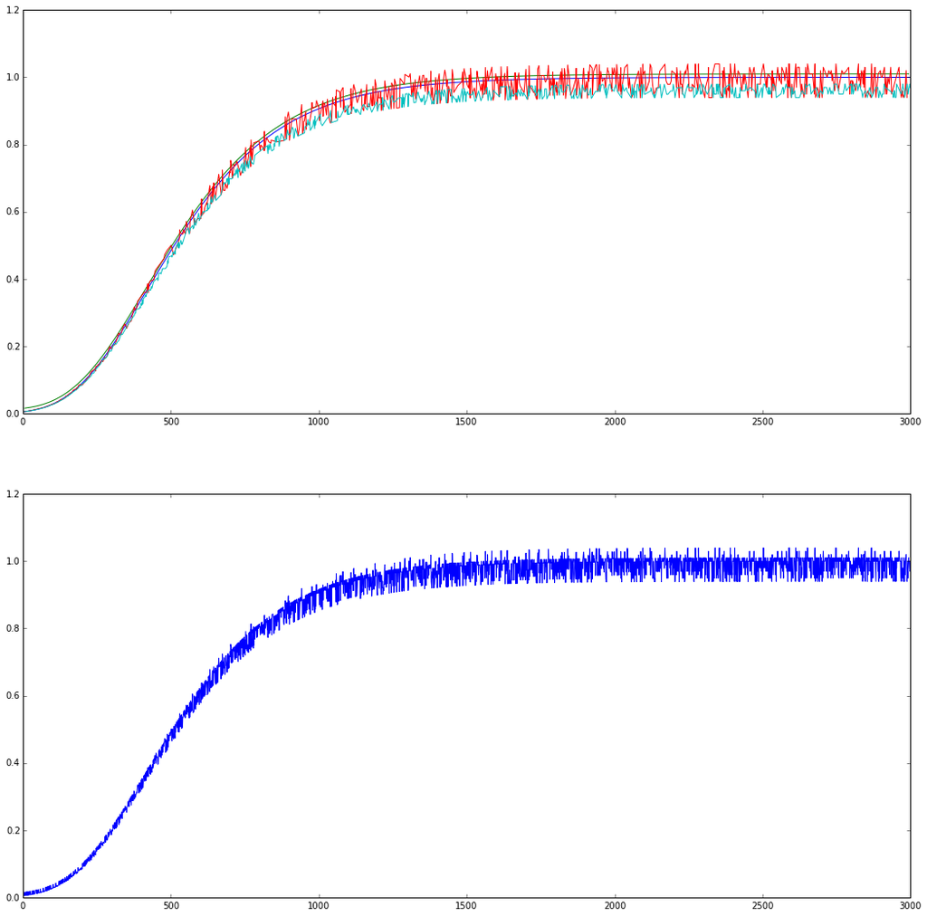

```python
#http://docs.scipy.org/doc/numpy/reference/arrays.indexing.html
#http://docs.scipy.org/doc/numpy-1.10.1/reference/generated/numpy.random.normal.html

import subprocess
import csv
import random
import math as mt
import numpy as np
import matplotlib.pylab as plt
%matplotlib inline

def numpy_random(n):
    """Return a list of n random floats in the range [0, 1)."""
    return np.random.random((n)).tolist()

def numpy_randint(a, b, n):
    """Return a list of n random ints in the range [a, b]."""
    return np.random.randint(a, b, n).tolist()

def numpy_gauss(a, b, c):
    """Return a list of gaussian distributed ints centered at a, with std b, and size c"""
    return np.random.normal(a, b, c).tolist()

#create an array of random numbers
#growth curve formula y(t) = a * exp(-b(exp(-ct)))
#a is an asymptote
#b,c are positive
#b translates the graph to the left or right
#c sets the growth rate (y scaling)


###shuffled array of narnians
f = 'peter'
g = 'lucy'
h = 'edmond'
i = 'susan'
b = []
for k in range(3000):
    b.append(f)
    b.append(g)
    b.append(h)
    b.append(i)
    k + 4
random.shuffle(b)


###growth curves
t = np.arange(1,31,0.01)
a1 = 1
b1 = -8
c3 = 0.4
y3 = a1 * np.exp(b1*np.exp(-c3*t))


###throw a rock at the growth curves
final = np.zeros((3000,2), dtype=object)
for k in range(3000):
    if b[k] == 'peter':
        y3[k] = y3[k]
        final[k,1] = ['peter']
        final[k,0] = y3[k]
        w.append(y3[k])
        wx.append(k)
    elif b[k] == 'lucy':
        y3[k] = y3[k] + 0.01
        final[k,1] = ['lucy']
        final[k,0] = y3[k]
        x.append(y3[k])
        xx.append(k)
    elif b[k] == 'edmond':
        y3[k] = y3[k] * np.random.randint(94, 105, 1)*0.01
        final[k,1] = ['edmond']
        final[k,0] = y3[k]
        y.append(y3[k])
        yx.append(k)
    elif b[k] == 'susan':
        y3[k] = y3[k] * np.random.randint(94, 99, 1)*0.01
        final[k,1] = ['susan']
        final[k,0] = y3[k]
        z.append(y3[k])
        zx.append(k)

###plot that stuff
fig = plt.figure(figsize=(18,18))
plt1 = fig.add_subplot(211)
plt1.plot(wx, w)
plt1.plot(xx, x)
plt1.plot(yx, y)
plt1.plot(zx, z)
plt2 = fig.add_subplot(212)
plt2.plot(y3)


with open('class_data.csv', 'wb') as csvfile:
    spamwriter = csv.writer(csvfile, delimiter='\n',
                             quoting=csv.QUOTE_MINIMAL)
    spamwriter.writerow(final)
```

# Lab Data

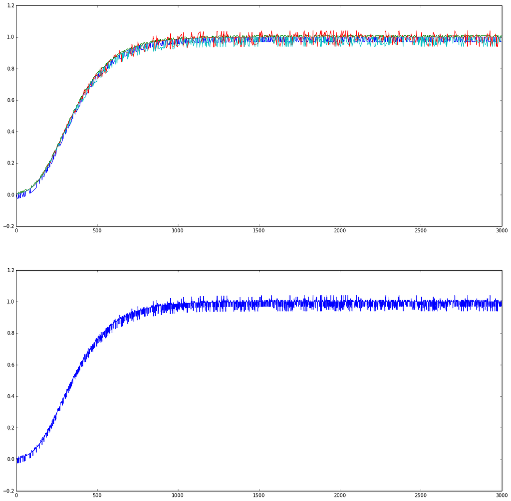

```python
#http://docs.scipy.org/doc/numpy/reference/arrays.indexing.html
#http://docs.scipy.org/doc/numpy-1.10.1/reference/generated/numpy.random.normal.html

import subprocess
import csv
import random
import math as mt
import numpy as np
import matplotlib.pylab as plt
%matplotlib inline

def numpy_random(n):
    """Return a list of n random floats in the range [0, 1)."""
    return np.random.random((n)).tolist()

def numpy_randint(a, b, n):
    """Return a list of n random ints in the range [a, b]."""
    return np.random.randint(a, b, n).tolist()

def numpy_gauss(a, b, c):
    """Return a list of gaussian distributed ints centered at a, with std b, and size c"""
    return np.random.normal(a, b, c).tolist()

#create an array of random numbers
#growth curve formula y(t) = a * exp(-b(exp(-ct)))
#a is an asymptote
#b,c are positive
#b translates the graph to the left or right
#c sets the growth rate (y scaling)


###shuffled array of gunslingers
f = 'roland'
g = 'susannah'
h = 'eddie'
i = 'jake'
researcher = []
for k in range(3000):
    researcher.append(f)
    researcher.append(g)
    researcher.append(h)
    researcher.append(i)
    k + 4
random.shuffle(researcher)

###shuffled array of glucose monitors
f = 'Man_OD'
g = 'UV-Vis'
monitor = []
for k in range(3000):
    monitor.append(f)
    monitor.append(g)
    k + 2
random.shuffle(monitor)

###growth curves
t = np.arange(1,31,0.01)
a1 = 1
b1 = -10
c3 = 0.6
y3 = a1 * np.exp(b1*np.exp(-c3*t))

###throw a rock at the growth curves
r1 = numpy_random(3000)
r2 = numpy_randint(90, 100, 3000)
r2 = [x * 0.01 for x in r2]

w = []
x = []
y = []
z = []
wx = []
xx = []
yx = []
zx = []
final = np.zeros((3000,3), dtype=object)

for k in range(3000):
    if researcher[k] == 'roland' and monitor[k] == 'Man_OD':
        y3[k] = y3[k] -0.03
        final[k,2] = ['Man_OD']
        final[k,1] = ['roland']
        final[k,0] = y3[k]
        w.append(y3[k])
        wx.append(k)
    elif researcher[k] == 'roland' and monitor[k] == 'UV-Vis':
        y3[k] = y3[k]
        final[k,2] = ['UV_Vis']
        final[k,1] = ['roland']
        final[k,0] = y3[k]
        w.append(y3[k])
        wx.append(k)
    elif researcher[k] == 'susannah' and monitor[k] == 'Man_OD':
        y3[k] = y3[k] + 0.01
        final[k,2] = ['Man_OD']
        final[k,1] = ['susannah']
        final[k,0] = y3[k]
        x.append(y3[k])
        xx.append(k)
    elif researcher[k] == 'susannah' and monitor[k] == 'UV-Vis':
        y3[k] = y3[k]
        final[k,2] = ['UV-Vis']
        final[k,1] = ['susannah']
        final[k,0] = y3[k]
        x.append(y3[k])
        xx.append(k)
    elif researcher[k] == 'eddie' and monitor[k] == 'Man_OD':
        y3[k] = y3[k] * np.random.randint(94, 105, 1)*0.01
        final[k,2] = ['Man_OD']
        final[k,1] = ['eddie']
        final[k,0] = y3[k]
        y.append(y3[k])
        yx.append(k)
    elif researcher[k] == 'eddie' and monitor[k] == 'UV-Vis':
        y3[k] = y3[k]
        final[k,2] = ['UV-Vis']
        final[k,1] = ['eddie']
        final[k,0] = y3[k]
        y.append(y3[k])
        yx.append(k)
    elif researcher[k] == 'jake' and monitor[k] == 'Man_OD':
        y3[k] = y3[k] * np.random.randint(94, 99, 1)*0.01
        final[k,2] = ['Man_OD']
        final[k,1] = ['jake']
        final[k,0] = y3[k]
        z.append(y3[k])
        zx.append(k)
    elif researcher[k] == 'jake' and monitor[k] == 'UV-Vis':
        y3[k] = y3[k]
        final[k,2] = ['UV-Vis']
        final[k,1] = ['jake']
        final[k,0] = y3[k]
        z.append(y3[k])
        zx.append(k)

###plot that stuff
fig = plt.figure(figsize=(18,18))
plt1 = fig.add_subplot(211)
plt1.plot(wx, w)
plt1.plot(xx, x)
plt1.plot(yx, y)
plt1.plot(zx, z)
plt2 = fig.add_subplot(212)
plt2.plot(y3)


with open('homework_data.csv', 'wb') as csvfile:
    spamwriter = csv.writer(csvfile, delimiter='\n',
                             quoting=csv.QUOTE_MINIMAL)
    spamwriter.writerow(final)
```

# Homework Data

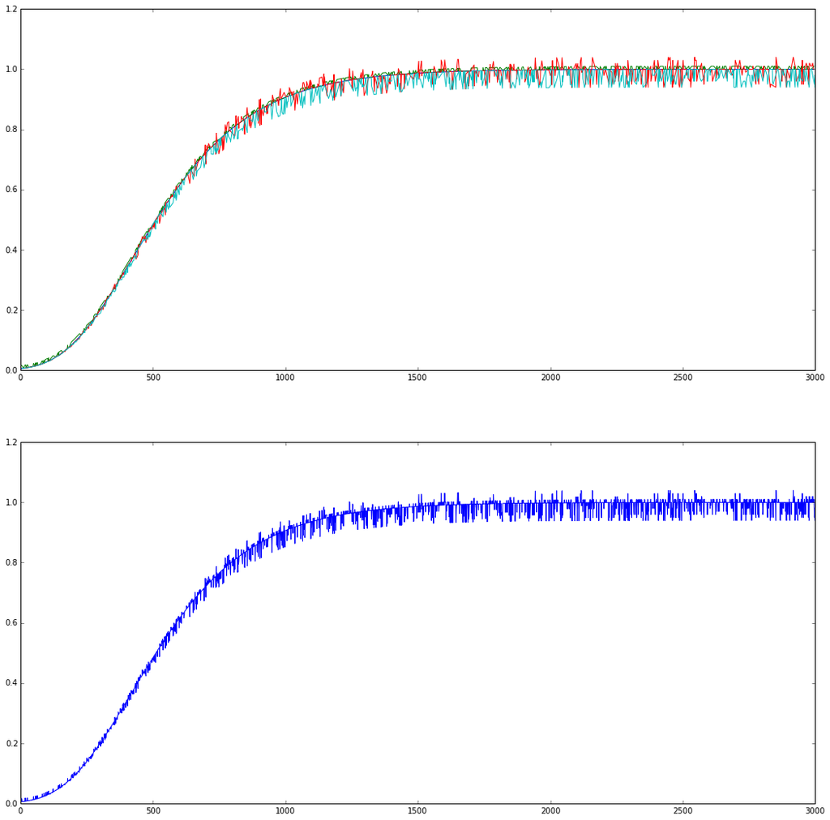

```python
#http://docs.scipy.org/doc/numpy/reference/arrays.indexing.html
#http://docs.scipy.org/doc/numpy-1.10.1/reference/generated/numpy.random.normal.html

import subprocess
import csv
import random
import math as mt
import numpy as np
import matplotlib.pylab as plt
%matplotlib inline

def numpy_random(n):
    """Return a list of n random floats in the range [0, 1)."""
    return np.random.random((n)).tolist()

def numpy_randint(a, b, n):
    """Return a list of n random ints in the range [a, b]."""
    return np.random.randint(a, b, n).tolist()

def numpy_gauss(a, b, c):
    """Return a list of gaussian distributed ints centered at a, with std b, and size c"""
    return np.random.normal(a, b, c).tolist()

#create an array of random numbers
#growth curve formula y(t) = a * exp(-b(exp(-ct)))
#a is an asymptote
#b,c are positive
#b translates the graph to the left or right
#c sets the growth rate (y scaling)


###shuffled array of researchers
f = 'roland'
g = 'susannah'
h = 'eddie'
i = 'jake'
researcher = []
for k in range(3000):
    researcher.append(f)
    researcher.append(g)
    researcher.append(h)
    researcher.append(i)
    k + 4
random.shuffle(researcher)

###shuffled array of glucose monitors
f = 'Man_OD'
g = 'UV-Vis'
monitor = []
for k in range(3000):
    monitor.append(f)
    monitor.append(g)
    k + 2
random.shuffle(monitor)

###growth curves
t = np.arange(1,31,0.01)
a1 = 1
b1 = -8
c1 = 0.4
c2 = 0.4
c3 = 0.4
y1 = a1 * np.exp(b1*np.exp(-c1*t))
y2 = a1 * np.exp(b1*np.exp(-c2*t))
y3 = a1 * np.exp(b1*np.exp(-c3*t))

#for k in range(3000):
#    f = np.random.randint(30, 300, 1)
#    y1[f] = y1[f] * np.random.randint(80, 120, 1)*0.01
#    y1[k+1] = y1[k] + np.random.randint()


###throw a rock at the growth curves
r1 = numpy_random(3000)
r2 = numpy_randint(90, 100, 3000)
r2 = [x * 0.01 for x in r2]

y1 = y1 * r1
y2 = y2 * r2

w = []
x = []
y = []
z = []
wx = []
xx = []
yx = []
zx = []
final = np.zeros((3000,3), dtype=object)

for k in range(3000):
    if researcher[k] == 'roland' and monitor[k] == 'Man_OD':
        y3[k] = y3[k]
        final[k,2] = ['Man_OD']
        final[k,1] = ['roland']
        final[k,0] = y3[k]
        w.append(y3[k])
        wx.append(k)
    elif researcher[k] == 'roland' and monitor[k] == 'UV-Vis':
        y3[k] = y3[k]
        final[k,2] = ['UV_Vis']
        final[k,1] = ['roland']
        final[k,0] = y3[k]
        w.append(y3[k])
        wx.append(k)
    elif researcher[k] == 'susannah' and monitor[k] == 'Man_OD':
        y3[k] = y3[k] + 0.01
        final[k,2] = ['Man_OD']
        final[k,1] = ['susannah']
        final[k,0] = y3[k]
        x.append(y3[k])
        xx.append(k)
    elif researcher[k] == 'susannah' and monitor[k] == 'UV-Vis':
        y3[k] = y3[k]
        final[k,2] = ['UV-Vis']
        final[k,1] = ['susannah']
        final[k,0] = y3[k]
        x.append(y3[k])
        xx.append(k)
    elif researcher[k] == 'eddie' and monitor[k] == 'Man_OD':
        y3[k] = y3[k] * np.random.randint(94, 105, 1)*0.01
        final[k,2] = ['Man_OD']
        final[k,1] = ['eddie']
        final[k,0] = y3[k]
        y.append(y3[k])
        yx.append(k)
    elif researcher[k] == 'eddie' and monitor[k] == 'UV-Vis':
        y3[k] = y3[k]
        final[k,2] = ['UV-Vis']
        final[k,1] = ['eddie']
        final[k,0] = y3[k]
        y.append(y3[k])
        yx.append(k)
    elif researcher[k] == 'jake' and monitor[k] == 'Man_OD':
        y3[k] = y3[k] * np.random.randint(94, 99, 1)*0.01
        final[k,2] = ['Man_OD']
        final[k,1] = ['jake']
        final[k,0] = y3[k]
        z.append(y3[k])
        zx.append(k)
    elif researcher[k] == 'jake' and monitor[k] == 'UV-Vis':
        y3[k] = y3[k]
        final[k,2] = ['UV-Vis']
        final[k,1] = ['jake']
        final[k,0] = y3[k]
        z.append(y3[k])
        zx.append(k)

###plot that stuff
fig = plt.figure(figsize=(18,18))
plt1 = fig.add_subplot(211)
plt1.plot(wx, w)
plt1.plot(xx, x)
plt1.plot(yx, y)
plt1.plot(zx, z)
plt2 = fig.add_subplot(212)
plt2.plot(y3)


with open('homework_data.csv', 'wb') as csvfile:
    spamwriter = csv.writer(csvfile, delimiter='\n',
                             quoting=csv.QUOTE_MINIMAL)
    spamwriter.writerow(final)
```